# **TeamTacobell - Fall 2025 Data Science Project**

# **Contributions**

Hetansh Kevadia - Responsible for helping develop the original project idea, performing primary analysis, and helped produce main visualizations and interpretation. Also contributed to formatting and writing the final tutorial and results discussion.

Tanya Grover - I was responsible for helping develop the original product idea, contributing to the dataset curation and preprocessing, and implementing the "exploratory data analysis" section. I also helped with the development of the ML Algorithm design and the visualization of our data.

Shyam Polisetty - I was responsible for helping develop the original product idea, initial data curation and the write-up involving writing the introduction, data analysis, insights and conclusions.

Kaavya Radhakrishnan - I worked on formatting, as well as deploying the final project to GitHub. I helped with data curation through finding datasets on Kaggle, and contributed to ML Algorithm design and result analysis.

Sid Belwal - I was responsible for helping develop the original project idea, supporting data curation, and contributing to the write up through writing parts of the methodology, analysis, and final conclusions.

```python
import pandas as pd
import numpy as np
import seaborn as sns
import matplotlib.pyplot as plt
from scipy.stats import ttest_ind, zscore
import statsmodels.api as sm
from scipy.stats import linregress
from scipy.stats import chi2_contingency
from sklearn.metrics import ConfusionMatrixDisplay
from sklearn.ensemble import RandomForestClassifier
from sklearn.model_selection import train_test_split
from sklearn.linear_model import LogisticRegression
from sklearn.metrics import (
    accuracy_score, confusion_matrix, classification_report,
    roc_curve, auc
)
from imblearn.over_sampling import SMOTE
```

# **Introduction:**

Music streaming platforms like Spotify have become central to how people discover and consume music globally. However, the factors that make a song successful on these platforms remain unclear to artists and producers. This analysis explores what audio characteristics drive streaming popularity by examining data from Spotify's top 2023 songs alongside TikTok metrics.

Key Research Questions:

- Which audio features (loudness, energy, danceability) are associated with higher streaming counts?
- Is listener attention concentrated among a few dominant artists?
- Can we predict a song's virality potential based on its audio characteristics?

Understanding these patterns will help artists and producers optimize their music for streaming success and provide data-driven insights into listener preferences.

# **Data Curation**

Our analysis integrates data from three primary sources:

# **Data preprocessing**

In this section we load the three datasets into pandas DataFrames using the **read_csv** function. We print the shape of each dataset so we can confirm that the data loaded correctly and to get an idea of how many songs and features we are working with.

Next, we clean the column names by making them **lowercase** and **replacing spaces with underscores**. This makes the data easier to use in Python because the column names become simpler and more consistent. After that, we **rename the main song and artist columns** so that both datasets use the same names. This step matters because it will allow us to join or compare the datasets later without running into naming problems. To make sure the cleaning process worked, we print the first few rows of each dataset. This helps us see what the data looks like and check that important features like streaming numbers, playlist counts, danceability, energy, and loudness are present. It also gives us an early sense of how the Spotify and TikTok datasets differ.

```python
spotify23_df = pd.read_csv("spotify-2023.csv", encoding="latin1")
tiktok_df    = pd.read_csv("TikTok_songs_2022.csv", encoding="latin1")
random_df = pd.read_csv("song_tracks.csv", encoding="latin1")
print("Spotify 2023 shape:", spotify23_df.shape)
print("TikTok shape:", tiktok_df.shape)
print("Random df shape:", random_df.shape)
for df in [spotify23_df, tiktok_df]:
    df.columns = df.columns.str.lower().str.replace(" ", "_")
spotify23_df.rename(columns={"track_name": "song", "artist(s)_name": "artist"}, inplace=True)
tiktok_df.rename(columns={"track_name": "song", "artist_name": "artist"}, inplace=True)
```

```
Spotify 2023 shape: (953, 24)
TikTok shape: (263, 18)
Random df shape: (20594, 24)
```

```python
print("Spotify 2023 (sample):")
spotify23_df
```

```
Spotify 2023 (sample):
```

|  | song | artist | artist_count | released_year | released_month | released_day | in_spotify_playlists | in_spotify_charts | streams | in_apple_playlists | ... | bpm | key | mode | danceability_% | valence_% | energy_% | acousticness_% | instrumentalness_% | liveness_% | speechiness_% |
| --- | --- | --- | --- | --- | --- | --- | --- | --- | --- | --- | --- | --- | --- | --- | --- | --- | --- | --- | --- | --- | --- |
| 0 | Seven (feat. Latto) (Explicit Ver.) | Latto, Jung Kook | 2 | 2023 | 7 | 14 | 553 | 147 | 141381703 | 43 | ... | 125 | B | Major | 80 | 89 | 83 | 31 | 0 | 8 | 4 |
| 1 | LALA | Myke Towers | 1 | 2023 | 3 | 23 | 1474 | 48 | 133716286 | 48 | ... | 92 | C# | Major | 71 | 61 | 74 | 7 | 0 | 10 | 4 |
| 2 | vampire | Olivia Rodrigo | 1 | 2023 | 6 | 30 | 1397 | 113 | 140003974 | 94 | ... | 138 | F | Major | 51 | 32 | 53 | 17 | 0 | 31 | 6 |
| 3 | Cruel Summer | Taylor Swift | 1 | 2019 | 8 | 23 | 7858 | 100 | 800840817 | 116 | ... | 170 | A | Major | 55 | 58 | 72 | 11 | 0 | 11 | 15 |
| 4 | WHERE SHE GOES | Bad Bunny | 1 | 2023 | 5 | 18 | 3133 | 50 | 303236322 | 84 | ... | 144 | A | Minor | 65 | 23 | 80 | 14 | 63 | 11 | 6 |
| ... | ... | ... | ... | ... | ... | ... | ... | ... | ... | ... | ... | ... | ... | ... | ... | ... | ... | ... | ... | ... | ... |
| 948 | My Mind & Me | Selena Gomez | 1 | 2022 | 11 | 3 | 953 | 0 | 91473363 | 61 | ... | 144 | A | Major | 60 | 24 | 39 | 57 | 0 | 8 | 3 |
| 949 | Bigger Than The Whole Sky | Taylor Swift | 1 | 2022 | 10 | 21 | 1180 | 0 | 121871870 | 4 | ... | 166 | F# | Major | 42 | 7 | 24 | 83 | 1 | 12 | 6 |
| 950 | A Veces (feat. Feid) | Feid, Paulo Londra | 2 | 2022 | 11 | 3 | 573 | 0 | 73513683 | 2 | ... | 92 | C# | Major | 80 | 81 | 67 | 4 | 0 | 8 | 6 |
| 951 | En La De Ella | Feid, Sech, Jhayco | 3 | 2022 | 10 | 20 | 1320 | 0 | 133895612 | 29 | ... | 97 | C# | Major | 82 | 67 | 77 | 8 | 0 | 12 | 5 |
| 952 | Alone | Burna Boy | 1 | 2022 | 11 | 4 | 782 | 2 | 96007391 | 27 | ... | 90 | E | Minor | 61 | 32 | 67 | 15 | 0 | 11 | 5 |

953 rows × 24 columns

```python
print("TikTok (sample):")
tiktok_df
```

```
TikTok (sample):
```

|  | song | artist | artist_pop | album | track_pop | danceability | energy | loudness | mode | key | speechiness | acousticness | instrumentalness | liveness | valence | tempo | time_signature | duration_ms |
| --- | --- | --- | --- | --- | --- | --- | --- | --- | --- | --- | --- | --- | --- | --- | --- | --- | --- | --- |
| 0 | Running Up That Hill (A Deal With God) | Kate Bush | 81 | Hounds Of Love | 95 | 0.629 | 0.547 | -13.123 | 0 | 10 | 0.0550 | 0.720000 | 0.003140 | 0.0604 | 0.197 | 108.375 | 4 | 298933 |
| 1 | As It Was | Harry Styles | 91 | As It Was | 96 | 0.520 | 0.731 | -5.338 | 0 | 6 | 0.0557 | 0.342000 | 0.001010 | 0.3110 | 0.662 | 173.930 | 4 | 167303 |
| 2 | Sunroof | Nicky Youre | 73 | Sunroof | 44 | 0.768 | 0.716 | -5.110 | 1 | 10 | 0.0404 | 0.350000 | 0.000000 | 0.1500 | 0.841 | 131.430 | 4 | 163026 |
| 3 | Heat Waves | Glass Animals | 80 | Dreamland (+ Bonus Levels) | 89 | 0.761 | 0.525 | -6.900 | 1 | 11 | 0.0944 | 0.440000 | 0.000007 | 0.0921 | 0.531 | 80.870 | 4 | 238805 |
| 4 | About Damn Time | Lizzo | 81 | About Damn Time | 92 | 0.836 | 0.743 | -6.305 | 0 | 10 | 0.0656 | 0.099500 | 0.000000 | 0.3350 | 0.722 | 108.966 | 4 | 191822 |
| ... | ... | ... | ... | ... | ... | ... | ... | ... | ... | ... | ... | ... | ... | ... | ... | ... | ... | ... |
| 258 | The Less I Know The Better | Tame Impala | 78 | Currents | 84 | 0.640 | 0.740 | -4.083 | 1 | 4 | 0.0284 | 0.011500 | 0.006780 | 0.1670 | 0.785 | 116.879 | 4 | 216320 |
| 259 | Dandelions | Ruth B. | 75 | Safe Haven | 90 | 0.609 | 0.692 | -2.958 | 1 | 1 | 0.0259 | 0.015700 | 0.000000 | 0.0864 | 0.454 | 116.959 | 3 | 233720 |
| 260 | Jimmy Cooks (feat. 21 Savage) | Drake | 95 | Honestly, Nevermind | 92 | 0.529 | 0.673 | -4.711 | 1 | 0 | 0.1750 | 0.000307 | 0.000002 | 0.0930 | 0.366 | 165.921 | 4 | 218365 |
| 261 | Good Looking | Suki Waterhouse | 64 | Good Looking | 80 | 0.377 | 0.558 | -9.076 | 1 | 4 | 0.0299 | 0.078900 | 0.000342 | 0.1250 | 0.267 | 149.971 | 3 | 214800 |
| 262 | INFERNO | Sub Urban | 67 | INFERNO | 71 | 0.820 | 0.611 | -5.020 | 0 | 9 | 0.1220 | 0.076600 | 0.000025 | 0.0684 | 0.637 | 127.883 | 4 | 133134 |

263 rows × 18 columns

```python
print("Random tracks (sample):")
random_df
```

```
Random tracks (sample):
```

|  | Artist | Track | Album | Album_type | Danceability | Energy | Loudness | Speechiness | Acousticness | Instrumentalness | ... | Title | Channel | Views | Likes | Comments | Licensed | official_video | Stream | EnergyLiveness | most_playedon |
| --- | --- | --- | --- | --- | --- | --- | --- | --- | --- | --- | --- | --- | --- | --- | --- | --- | --- | --- | --- | --- | --- |
| 0 | Gorillaz | Feel Good Inc. | Demon Days | album | 0.818 | 0.705 | -6.679 | 0.1770 | 0.008360 | 0.002330 | ... | Gorillaz - Feel Good Inc. (Official Video) | Gorillaz | 693555221 | 6220896 | 169907 | True | True | 1040234854 | 1.150082 | Spotify |
| 1 | Gorillaz | Rhinestone Eyes | Plastic Beach | album | 0.676 | 0.703 | -5.815 | 0.0302 | 0.086900 | 0.000687 | ... | Gorillaz - Rhinestone Eyes [Storyboard Film] (... | Gorillaz | 72011645 | 1079128 | 31003 | True | True | 310083733 | 15.183585 | Spotify |
| 2 | Gorillaz | New Gold (feat. Tame Impala and Bootie Brown) | New Gold (feat. Tame Impala and Bootie Brown) | single | 0.695 | 0.923 | -3.930 | 0.0522 | 0.042500 | 0.046900 | ... | Gorillaz - New Gold ft. Tame Impala & Bootie B... | Gorillaz | 8435055 | 282142 | 7399 | True | True | 63063467 | 7.956897 | Spotify |
| 3 | Gorillaz | On Melancholy Hill | Plastic Beach | album | 0.689 | 0.739 | -5.810 | 0.0260 | 0.000015 | 0.509000 | ... | Gorillaz - On Melancholy Hill (Official Video) | Gorillaz | 211754952 | 1788577 | 55229 | True | True | 434663559 | 11.546875 | Spotify |
| 4 | Gorillaz | Clint Eastwood | Gorillaz | album | 0.663 | 0.694 | -8.627 | 0.1710 | 0.025300 | 0.000000 | ... | Gorillaz - Clint Eastwood (Official Video) | Gorillaz | 618480958 | 6197318 | 155930 | True | True | 617259738 | 9.942693 | Youtube |
| ... | ... | ... | ... | ... | ... | ... | ... | ... | ... | ... | ... | ... | ... | ... | ... | ... | ... | ... | ... | ... | ... |
| 20589 | SICK LEGEND | JUST DANCE HARDSTYLE | JUST DANCE HARDSTYLE | single | 0.582 | 0.926 | -6.344 | 0.0328 | 0.448000 | 0.000000 | ... | JUST DANCE HARDSTYLE | SICK LEGEND - Topic | 71678 | 1113 | 0 | True | True | 9227144 | 11.036949 | Spotify |
| 20590 | SICK LEGEND | SET FIRE TO THE RAIN HARDSTYLE | SET FIRE TO THE RAIN HARDSTYLE | single | 0.531 | 0.936 | -1.786 | 0.1370 | 0.028000 | 0.000000 | ... | SET FIRE TO THE RAIN HARDSTYLE | SICK LEGEND - Topic | 164741 | 2019 | 0 | True | True | 10898176 | 10.140845 | Spotify |
| 20591 | SICK LEGEND | OUTSIDE HARDSTYLE SPED UP | OUTSIDE HARDSTYLE SPED UP | single | 0.443 | 0.830 | -4.679 | 0.0647 | 0.024300 | 0.000000 | ... | OUTSIDE HARDSTYLE SPED UP | SICK LEGEND - Topic | 35646 | 329 | 0 | True | True | 6226110 | 5.389610 | Spotify |
| 20592 | SICK LEGEND | ONLY GIRL HARDSTYLE | ONLY GIRL HARDSTYLE | single | 0.417 | 0.767 | -4.004 | 0.4190 | 0.356000 | 0.018400 | ... | ONLY GIRL HARDSTYLE | SICK LEGEND - Topic | 6533 | 88 | 0 | True | True | 6873961 | 7.101852 | Spotify |
| 20593 | SICK LEGEND | MISS YOU HARDSTYLE | MISS YOU HARDSTYLE | single | 0.498 | 0.938 | -4.543 | 0.1070 | 0.002770 | 0.911000 | ... | MISS YOU HARDSTYLE | SICK LEGEND - Topic | 158697 | 2484 | 0 | True | True | 5695584 | 6.897059 | Spotify |

20594 rows × 24 columns

We then merge the Spotify and TikTok datasets together using an inner join on the common columns, "song" and "artist", to create a single merged_df. This makes sure that every song we analyze has both Spotify and TikTok information. After merging, we remove any duplicate columns that came from combining the two datasets.

We check which of these features actually exist in the merged dataset and convert those columns into numeric values as well. After that, we remove any rows that are missing values for streams or the selected audio features. This leaves us with a clean dataset that is ready for analysis. At the end of this step, we print the number of songs left and the list of features we are analyzing.

```python
merged_df = pd.merge(spotify23_df, tiktok_df, on=["song", "artist"], how="inner")
merged_df = merged_df.loc[:, ~merged_df.columns.duplicated()].copy()
if "streams" in merged_df.columns:
    merged_df["streams"] = (
        merged_df["streams"]
        .astype(str)
        .replace(",", "", regex=True)
        .replace("nan", None)
    )
    merged_df["streams"] = pd.to_numeric(merged_df["streams"])
features = ["danceability", "energy", "loudness", "mode", "key"]
available_features = [f for f in features if f in merged_df.columns]
for col in available_features:
    merged_df[col] = pd.to_numeric(merged_df[col], errors="coerce")
merged_df.head()
merged_df = merged_df.dropna(subset=["streams"] + available_features)
print(f"Clean merged dataset: {merged_df.shape[0]} songs")
print("Analyzing features:", available_features)
```

```
Clean merged dataset: 41 songs
Analyzing features: ['danceability', 'energy', 'loudness']
```

```python
merged_df
```

|  | song | artist | artist_count | released_year | released_month | released_day | in_spotify_playlists | in_spotify_charts | streams | in_apple_playlists | ... | mode_y | key_y | speechiness | acousticness | instrumentalness | liveness | valence | tempo | time_signature | duration_ms |
| --- | --- | --- | --- | --- | --- | --- | --- | --- | --- | --- | --- | --- | --- | --- | --- | --- | --- | --- | --- | --- | --- |
| 0 | As It Was | Harry Styles | 1 | 2022 | 3 | 31 | 23575 | 130 | 2513188493 | 403 | ... | 0 | 6 | 0.0557 | 0.342000 | 0.001010 | 0.3110 | 0.662 | 173.930 | 4 | 167303 |
| 1 | Another Love | Tom Odell | 1 | 2012 | 10 | 15 | 18371 | 83 | 1813673666 | 250 | ... | 0 | 4 | 0.0400 | 0.695000 | 0.000017 | 0.0944 | 0.131 | 122.769 | 4 | 244360 |
| 2 | Blinding Lights | The Weeknd | 1 | 2019 | 11 | 29 | 43899 | 69 | 3703895074 | 672 | ... | 1 | 1 | 0.0598 | 0.001460 | 0.000095 | 0.0897 | 0.334 | 171.005 | 4 | 200040 |
| 3 | Blinding Lights | The Weeknd | 1 | 2019 | 11 | 29 | 43899 | 69 | 3703895074 | 672 | ... | 1 | 1 | 0.0629 | 0.001470 | 0.000209 | 0.0938 | 0.345 | 171.017 | 4 | 201573 |
| 4 | Heat Waves | Glass Animals | 1 | 2020 | 6 | 28 | 22543 | 63 | 2557975762 | 386 | ... | 1 | 11 | 0.0944 | 0.440000 | 0.000007 | 0.0921 | 0.531 | 80.870 | 4 | 238805 |
| 5 | Sweater Weather | The Neighbourhood | 1 | 2012 | 5 | 14 | 16413 | 61 | 2282771485 | 166 | ... | 1 | 10 | 0.0336 | 0.049500 | 0.017700 | 0.1010 | 0.398 | 124.053 | 4 | 240400 |
| 6 | Dandelions | Ruth B. | 1 | 2017 | 4 | 28 | 3423 | 21 | 1116995633 | 41 | ... | 1 | 1 | 0.0259 | 0.015700 | 0.000000 | 0.0864 | 0.454 | 116.959 | 3 | 233720 |
| 7 | SNAP | Rosa Linn | 1 | 2022 | 3 | 19 | 3202 | 18 | 726307468 | 148 | ... | 1 | 0 | 0.0684 | 0.107000 | 0.000011 | 0.4460 | 0.518 | 169.985 | 4 | 179551 |
| 8 | Bad Habit | Steve Lacy | 1 | 2022 | 6 | 29 | 8186 | 12 | 822633917 | 155 | ... | 1 | 1 | 0.0355 | 0.613000 | 0.000058 | 0.4020 | 0.700 | 168.946 | 4 | 232067 |
| 9 | Until I Found You | Stephen Sanchez | 1 | 2021 | 9 | 1 | 4427 | 4 | 726434358 | 69 | ... | 1 | 10 | 0.0288 | 0.727000 | 0.000000 | 0.1740 | 0.227 | 101.358 | 3 | 177720 |
| 10 | Glimpse of Us | Joji | 1 | 2022 | 6 | 10 | 6330 | 6 | 988515741 | 109 | ... | 1 | 8 | 0.0531 | 0.891000 | 0.000005 | 0.1410 | 0.268 | 169.914 | 3 | 233456 |
| 11 | Late Night Talking | Harry Styles | 1 | 2022 | 5 | 20 | 7461 | 8 | 743693613 | 166 | ... | 1 | 10 | 0.0468 | 0.298000 | 0.000000 | 0.1060 | 0.901 | 114.996 | 4 | 177955 |
| 12 | About Damn Time | Lizzo | 1 | 2022 | 7 | 15 | 2332 | 2 | 723894473 | 0 | ... | 0 | 10 | 0.0656 | 0.099500 | 0.000000 | 0.3350 | 0.722 | 108.966 | 4 | 191822 |
| 13 | Don't Start Now | Dua Lipa | 1 | 2019 | 10 | 31 | 27119 | 0 | 2303033973 | 532 | ... | 0 | 11 | 0.0842 | 0.012500 | 0.000000 | 0.0952 | 0.677 | 123.941 | 4 | 183290 |
| 14 | Running Up That Hill (A Deal With God) | Kate Bush | 1 | 1985 | 9 | 16 | 21811 | 0 | 1024858327 | 117 | ... | 0 | 10 | 0.0550 | 0.720000 | 0.003140 | 0.0604 | 0.197 | 108.375 | 4 | 298933 |
| 15 | Bad Habits | Ed Sheeran | 1 | 2020 | 9 | 3 | 12755 | 8 | 1555511105 | 344 | ... | 0 | 11 | 0.0348 | 0.046900 | 0.000031 | 0.3640 | 0.591 | 126.026 | 4 | 231041 |
| 16 | Good Days | SZA | 1 | 2020 | 12 | 24 | 10426 | 2 | 826623384 | 133 | ... | 0 | 1 | 0.0583 | 0.499000 | 0.000008 | 0.6880 | 0.412 | 121.002 | 4 | 279204 |
| 17 | Woman | Doja Cat | 1 | 2021 | 6 | 25 | 9424 | 0 | 1329090101 | 202 | ... | 0 | 5 | 0.0854 | 0.088800 | 0.002940 | 0.1170 | 0.881 | 107.998 | 4 | 172627 |
| 18 | I Hate U | SZA | 1 | 2021 | 12 | 3 | 4094 | 0 | 356709897 | 66 | ... | 0 | 7 | 0.1550 | 0.507000 | 0.000000 | 0.1100 | 0.412 | 106.703 | 5 | 174000 |
| 19 | good 4 u | Olivia Rodrigo | 1 | 2021 | 5 | 14 | 15563 | 6 | 1887039593 | 259 | ... | 1 | 9 | 0.1540 | 0.335000 | 0.000000 | 0.0849 | 0.688 | 166.928 | 4 | 178147 |
| 20 | MONTERO (Call Me By Your Name) | Lil Nas X | 1 | 2020 | 9 | 18 | 12329 | 0 | 1735441776 | 275 | ... | 0 | 8 | 0.1520 | 0.297000 | 0.000000 | 0.3840 | 0.758 | 178.818 | 4 | 137876 |
| 21 | THATS WHAT I WANT | Lil Nas X | 1 | 2021 | 9 | 17 | 7963 | 0 | 920797189 | 173 | ... | 0 | 1 | 0.2200 | 0.006140 | 0.000000 | 0.0486 | 0.546 | 87.981 | 4 | 143901 |
| 22 | drivers license | Olivia Rodrigo | 1 | 2021 | 1 | 8 | 12685 | 3 | 1858144199 | 185 | ... | 1 | 10 | 0.0601 | 0.721000 | 0.000013 | 0.1050 | 0.132 | 143.874 | 4 | 242014 |
| 23 | I AM WOMAN | Emmy Meli | 1 | 2021 | 11 | 18 | 2795 | 0 | 225259194 | 45 | ... | 1 | 10 | 0.1570 | 0.122000 | 0.000000 | 0.1250 | 0.455 | 170.084 | 4 | 232813 |
| 24 | Todo De Ti | Rauw Alejandro | 1 | 2020 | 11 | 2 | 11975 | 8 | 1168642797 | 188 | ... | 0 | 3 | 0.0506 | 0.310000 | 0.000163 | 0.0932 | 0.342 | 127.949 | 4 | 199604 |
| 25 | Life Goes On | Oliver Tree | 1 | 2020 | 7 | 17 | 2868 | 0 | 501541661 | 43 | ... | 1 | 0 | 0.0760 | 0.186000 | 0.000000 | 0.1170 | 0.569 | 79.982 | 4 | 161803 |
| 26 | TO THE MOON | Jnr Choi | 1 | 2021 | 11 | 5 | 2979 | 0 | 245095641 | 44 | ... | 1 | 2 | 0.3460 | 0.045100 | 0.007580 | 0.1110 | 0.386 | 144.047 | 4 | 152137 |
| 27 | Freaks | Surf Curse | 1 | 2015 | 5 | 10 | 3006 | 3 | 824420218 | 23 | ... | 1 | 9 | 0.0466 | 0.000038 | 0.633000 | 0.0511 | 0.407 | 179.626 | 4 | 147062 |
| 28 | positions | Ariana Grande | 1 | 2020 | 10 | 23 | 8207 | 0 | 1252563873 | 175 | ... | 1 | 0 | 0.0864 | 0.468000 | 0.000000 | 0.0940 | 0.675 | 144.005 | 4 | 172325 |
| 29 | Pope Is a Rockstar | SALES | 1 | 2016 | 4 | 20 | 1966 | 0 | 156658366 | 4 | ... | 0 | 4 | 0.0287 | 0.850000 | 0.243000 | 0.1070 | 0.311 | 90.024 | 4 | 187333 |
| 30 | Astronaut In The Ocean | Masked Wolf | 1 | 2019 | 1 | 1 | 7191 | 0 | 1138474110 | 146 | ... | 0 | 4 | 0.0913 | 0.175000 | 0.000000 | 0.1500 | 0.472 | 149.996 | 4 | 132780 |
| 31 | RAPSTAR | Polo G | 1 | 2021 | 4 | 9 | 4731 | 0 | 797402345 | 141 | ... | 1 | 6 | 0.2420 | 0.410000 | 0.000000 | 0.1290 | 0.437 | 81.039 | 4 | 165926 |
| 32 | Light Switch | Charlie Puth | 1 | 2022 | 1 | 19 | 4049 | 0 | 500340342 | 119 | ... | 1 | 6 | 0.3060 | 0.105000 | 0.000335 | 0.0881 | 0.912 | 184.009 | 4 | 185681 |
| 33 | Lost | Frank Ocean | 1 | 2012 | 1 | 1 | 29499 | 11 | 822239726 | 124 | ... | 0 | 10 | 0.2260 | 0.031900 | 0.001220 | 0.1230 | 0.514 | 123.070 | 4 | 234093 |
| 34 | Envolver | Anitta | 1 | 2021 | 11 | 11 | 4673 | 2 | 546191065 | 123 | ... | 0 | 4 | 0.0833 | 0.152000 | 0.002540 | 0.0914 | 0.396 | 91.993 | 4 | 193806 |
| 35 | First Class | Jack Harlow | 1 | 2022 | 4 | 8 | 8737 | 0 | 694525298 | 163 | ... | 1 | 8 | 0.1020 | 0.025400 | 0.000010 | 0.1130 | 0.324 | 106.998 | 4 | 173948 |
| 36 | Ain't Shit | Doja Cat | 1 | 2021 | 6 | 25 | 3436 | 0 | 499710590 | 32 | ... | 1 | 3 | 0.2080 | 0.506000 | 0.000000 | 0.3470 | 0.619 | 124.097 | 4 | 174253 |
| 37 | About Damn Time | Lizzo | 1 | 2022 | 4 | 14 | 9021 | 0 | 723894473 | 242 | ... | 0 | 10 | 0.0656 | 0.099500 | 0.000000 | 0.3350 | 0.722 | 108.966 | 4 | 191822 |
| 38 | Good Looking | Suki Waterhouse | 1 | 2017 | 10 | 20 | 2264 | 0 | 184706613 | 11 | ... | 1 | 4 | 0.0299 | 0.078900 | 0.000342 | 0.1250 | 0.267 | 149.971 | 3 | 214800 |
| 39 | Betty (Get Money) | Yung Gravy | 1 | 2022 | 6 | 10 | 2402 | 0 | 221752937 | 45 | ... | 1 | 1 | 0.0792 | 0.005240 | 0.000012 | 0.3670 | 0.580 | 102.004 | 4 | 146471 |
| 40 | SNAP | Rosa Linn | 1 | 2022 | 3 | 19 | 1818 | 0 | 711366595 | 3 | ... | 1 | 0 | 0.0684 | 0.107000 | 0.000011 | 0.4460 | 0.518 | 169.985 | 4 | 179551 |

41 rows × 40 columns

# **Exploratory Data Analysis**

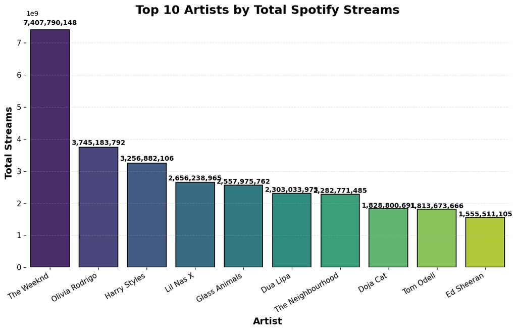

```python
plt.figure(figsize=(11,7))

if "streams" in merged_df.columns:
    top_artists = (
        merged_df.groupby("artist")["streams"]
        .sum()
        .sort_values(ascending=False)
        .head(10)
    )
    plot_df = top_artists.reset_index()
    plot_df.columns = ["Artist", "Total Streams"]

    colors = sns.color_palette("viridis", n_colors=len(plot_df))

    ax = sns.barplot(
    data=plot_df,
    x="Artist",
    y="Total Streams",
    hue="Artist",
    palette=colors,
    legend=False,
    edgecolor="black",
    linewidth=1.2
    )
    for i, v in enumerate(plot_df["Total Streams"]):
        ax.text(
            i, v + (v * 0.02),
            f"{v:,.0f}",
            ha="center", fontsize=10, fontweight="bold"
        )

    plt.title("Top 10 Artists by Total Spotify Streams", fontsize=18, weight='bold')
    plt.xlabel("Artist", fontsize=14, weight='semibold')
    plt.ylabel("Total Streams", fontsize=14, weight='semibold')

    plt.xticks(rotation=30, ha="right", fontsize=11)
    plt.yticks(fontsize=11)
    sns.despine(left=True, bottom=True)
    plt.grid(axis="y", linestyle="--", alpha=0.3)

    plt.tight_layout()
    plt.show()

else:
    print("'streams' column not found — skipping artist plot.")
```

After cleaning the data, we create a bar chart to show the top ten artists based on total Spotify streams. We group the dataset by artist and add up all the streams for each artist. Then we sort the artists from highest to lowest total streams and select the top ten.

This visualization is important because it shows how unequal music popularity can be in the streaming industry. It also supports our broader analysis of how artist dominance plays a role in song success.

```
Before filtering: 41 rows
After filtering:  39 rows
```

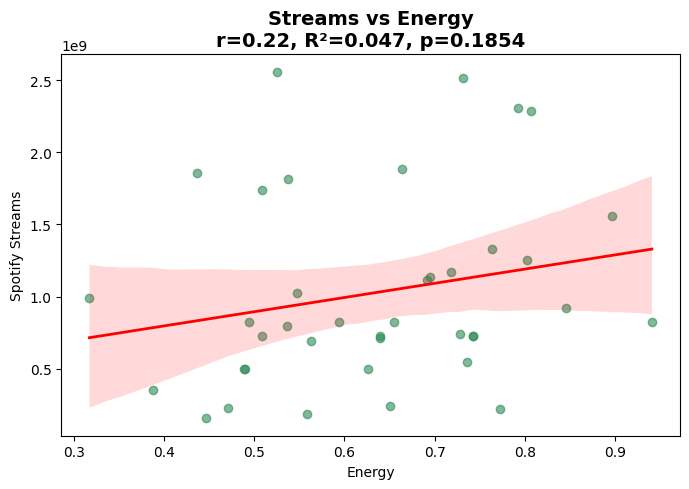

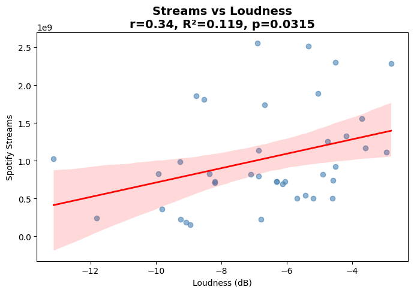

```
Linear Regression Results:
Energy → Streams: slope=983341695.08, R²=0.047, p=0.1854
Loudness → Streams: slope=95364278.29, R²=0.119, p=0.0315
```

```python
mean_streams = merged_df["streams"].mean()
std_streams = merged_df["streams"].std()

filtered_df = merged_df[
    (merged_df["streams"] >= mean_streams - 2 * std_streams) &
    (merged_df["streams"] <= mean_streams + 2 * std_streams)
]
print(f"Before filtering: {len(merged_df)} rows")
print(f"After filtering:  {len(filtered_df)} rows\n")
corr_energy = filtered_df["streams"].corr(filtered_df["energy"])
slope_e, intercept_e, r_e, p_e, std_err_e = linregress(
    filtered_df["energy"], filtered_df["streams"]
)

plt.figure(figsize=(7,5))
sns.regplot(
    data=filtered_df,
    x="energy",
    y="streams",
    scatter_kws={"alpha":0.6, "color":"#2E8B57"},
    line_kws={"color":"red", "lw":2}
)
plt.title(
    f"Streams vs Energy\nr={corr_energy:.2f}, R²={r_e**2:.3f}, p={p_e:.4f}",
    fontsize=14, weight="bold"
)
plt.xlabel("Energy")
plt.ylabel("Spotify Streams")
plt.tight_layout()
plt.show()
corr_loud = filtered_df["streams"].corr(filtered_df["loudness"])
slope_l, intercept_l, r_l, p_l, std_err_l = linregress(
    filtered_df["loudness"], filtered_df["streams"]
)

plt.figure(figsize=(7,5))
sns.regplot(
    data=filtered_df,
    x="loudness",
    y="streams",
    scatter_kws={"alpha":0.6, "color":"#4682B4"},
    line_kws={"color":"red", "lw":2}
)
plt.title(
    f"Streams vs Loudness\nr={corr_loud:.2f}, R²={r_l**2:.3f}, p={p_l:.4f}",
    fontsize=14, weight="bold"
)
plt.xlabel("Loudness (dB)")
plt.ylabel("Spotify Streams")
plt.tight_layout()
plt.show()
print("Linear Regression Results:")
print(f"Energy → Streams: slope={slope_e:.2f}, R²={r_e**2:.3f}, p={p_e:.4f}")
print(f"Loudness → Streams: slope={slope_l:.2f}, R²={r_l**2:.3f}, p={p_l:.4f}")
```

**Figure 2: Energy vs. Streams**

This plot shows a scattered relationship with no clear pattern, confirming that energy levels don't meaningfully predict popularity.

**Results**

The regression results show that loudness has a stronger and statistically significant relationship with Spotify streams (R² = 0.119, p = 0.0315), while energy shows a weaker and non-significant correlation (R² = 0.047, p = 0.1854). This suggests that louder tracks tend to receive more streams, possibly due to their higher perceived intensity and production quality. However, energy alone does not strongly predict popularity, indicating that other musical or external factors likely play a larger role in determining a song's streaming success.

Danceability measures how easy a song is to dance to, based on beat, rhythm, and tempo. Energy reflects a track's intensity and activity, and fast, loud, or dynamic songs score higher. Loudness is the overall volume in decibels, showing how “loud” a song sounds.

```
Contingency Table:

streams_bin       Low  Medium  High
danceability_bin
Low                 1       3     4
Medium              6       6     4
High                7       4     6

Chi-Squared Test Results:
Chi² Statistic = 2.996
Degrees of Freedom = 4
P-value = 0.5584
```

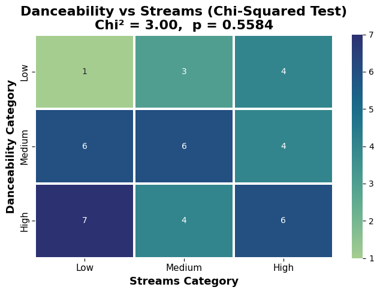

```python
merged_df["danceability_bin"] = pd.cut(
    merged_df["danceability"], bins=3, labels=["Low", "Medium", "High"]
)
merged_df["streams_bin"] = pd.qcut(
    merged_df["streams"], q=3, labels=["Low", "Medium", "High"]
)
contingency = pd.crosstab(merged_df["danceability_bin"], merged_df["streams_bin"])
print("\nContingency Table:\n")
print(contingency)
chi2, p, dof, expected = chi2_contingency(contingency)

print("\nChi-Squared Test Results:")
print(f"Chi² Statistic = {chi2:.3f}")
print(f"Degrees of Freedom = {dof}")
print(f"P-value = {p:.4f}")
plt.figure(figsize=(7,5))

sns.heatmap(
    contingency,
    annot=True,
    cmap="crest",
    fmt="d",
    linewidths=1.5,
    linecolor="white",
    cbar=True
)

plt.title(
    "Danceability vs Streams (Chi-Squared Test)\n"
    f"Chi² = {chi2:.2f},  p = {p:.4f}",
    fontsize=16, weight="bold"
)

plt.xlabel("Streams Category", fontsize=13, weight="semibold")
plt.ylabel("Danceability Category", fontsize=13, weight="semibold")

plt.xticks(fontsize=11)
plt.yticks(fontsize=11)

sns.despine(left=True, bottom=True)
plt.tight_layout()
plt.show()
```

**Figure 3: Danceability vs. Streams (Chi-Squared)**

**Hypotheses**

**Null Hypothesis (H₀):** There is no association between a song's danceability level and its Spotify stream category.

**Alternative Hypothesis (H₁):** There is an association between a song's danceability level and its Spotify stream category.

**Conclusion**

Since the Chi-Squared test produced a p-value of 0.5584, which is greater than 0.05, we fail to reject the null hypothesis. This means there is no statistically significant relationship between a song's danceability category and its popularity (measured by streams) - danceability alone does not appear to influence how often a song is streamed on Spotify.

# **Primary Analysis**

To investigate our final question, we developed a machine learning classification model using the larger Spotify Tracks with YouTube Metrics dataset to predict binary "virality" based on audio features. A song was labeled "viral" (Class 1) if its Spotify streams were in the top 20% (80th percentile) of the dataset. This resulted in an imbalanced dataset: 16,475 non-viral songs (Class 0) and 4,119 viral songs (Class 1). We used SMOTE (Synthetic Minority Over-sampling Technique) to address this imbalance in the training data and trained a Random Forest Classifier.

We chose the Random Forest Classifier for our prediction model because it's powerful and versatile. It works by building multiple decision trees and merges them together to get a more accurate prediction. We chose it because: The connection between a song's audio features (like Loudness or Energy) and its streaming success is probably non-linear. Random Forest handles these complexities effectively, which simpler linear models (like Logistic Regression) often struggle with. Some features (like Loudness and Energy) are often correlated with each other. We can handle multicollinearity by using a Random Forest. A Random Forest also gives us a reliable measure of feature importance; we can see which audio characteristics (instrumentality, loudness etc.) are the most valuable predictors of virality

```python
df = random_df
df = df.drop_duplicates()
df = df.dropna(subset=["Danceability", "Energy", "Loudness",
                  "Acousticness", "Speechiness", "Instrumentalness"])

numeric_cols = ["Danceability", "Energy", "Loudness",
                "Acousticness", "Speechiness", "Instrumentalness"]
for col in numeric_cols:
    df[col] = pd.to_numeric(df[col], errors="coerce")

df = df.dropna(subset=numeric_cols)
df["norm_engagement"] = (df["Likes"] / df["Views"]).rank(pct=True)
df["norm_conversion"] = (df["Stream"] / df["Views"]).rank(pct=True)
df["norm_streams"]    = df["Stream"].rank(pct=True)
df["viral_score"] = (
    0.5 * df["norm_engagement"] +
    0.3 * df["norm_conversion"] +
    0.2 * df["norm_streams"]
)

threshold = df["Stream"].quantile(0.80)
df["viral"] = (df["Stream"] >= threshold).astype(int)

print(df["viral"].value_counts())

X = df[["Danceability", "Energy", "Loudness",
        "Acousticness", "Speechiness", "Instrumentalness"]]
y = df["viral"]

X_train, X_test, y_train, y_test = train_test_split(
    X, y, test_size=0.20, random_state=42, stratify=y
)

sm = SMOTE(random_state=42)
X_train_res, y_train_res = sm.fit_resample(X_train, y_train)

log_model = RandomForestClassifier(
    n_estimators=300,
    class_weight="balanced",
    random_state=42
)
log_model.fit(X_train_res, y_train_res)

y_pred = log_model.predict(X_test)
y_prob = log_model.predict_proba(X_test)[:,1]

print("Accuracy:", accuracy_score(y_test, y_pred))
print("\nClassification Report:\n", classification_report(y_test, y_pred))

cm = confusion_matrix(y_test, y_pred)
```

```
viral
0    16475
1     4119
Name: count, dtype: int64
Accuracy: 0.7280893420733188

Classification Report:
               precision    recall  f1-score   support

           0       0.84      0.82      0.83      3295
           1       0.34      0.37      0.35       824

    accuracy                           0.73      4119
   macro avg       0.59      0.59      0.59      4119
weighted avg       0.74      0.73      0.73      4119
```

# **Visualization**

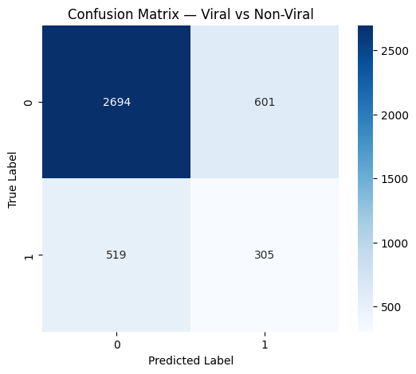

```python
plt.figure(figsize=(6,5))
sns.heatmap(cm, annot=True, fmt="d", cmap="Blues")
plt.xlabel("Predicted Label")
plt.ylabel("True Label")
plt.title("Confusion Matrix — Viral vs Non-Viral")
plt.show()
```

The confusion matrix above provides a clear, labeled visualization of how the model distinguishes between non-viral (0) and viral (1) songs. Each axis is labeled with true and predicted classes, the color bar indicates intensity, and the annotated counts help interpret the model's decisions.

[figure not shown]

```python
fpr, tpr, thresholds = roc_curve(y_test, y_prob)
roc_auc = auc(fpr, tpr)

plt.figure(figsize=(6,5))
plt.plot(fpr, tpr, label=f"AUC = {roc_auc:.2f}", linewidth=2)
plt.plot([0,1], [0,1], 'r--')
plt.xlabel("False Positive Rate")
plt.ylabel("True Positive Rate")
plt.title("ROC Curve — Logistic Regression")
plt.legend()
plt.show()
```

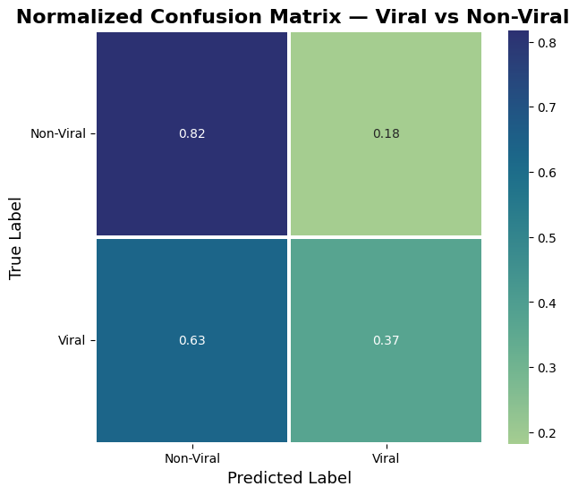

```python
plt.figure(figsize=(7,6))

cm = confusion_matrix(y_test, y_pred)
cm_norm = cm.astype("float") / cm.sum(axis=1)[:, np.newaxis]

sns.heatmap(
    cm_norm,
    annot=True,
    fmt=".2f",
    cmap="crest",
    cbar=True,
    linewidths=1.5,
    linecolor="white"
)

plt.title(" Normalized Confusion Matrix — Viral vs Non-Viral", fontsize=16, weight="bold")
plt.xlabel("Predicted Label", fontsize=13)
plt.ylabel("True Label", fontsize=13)
plt.xticks([0.5, 1.5], ["Non-Viral", "Viral"])
plt.yticks([0.5, 1.5], ["Non-Viral", "Viral"], rotation=0)
plt.show()
```

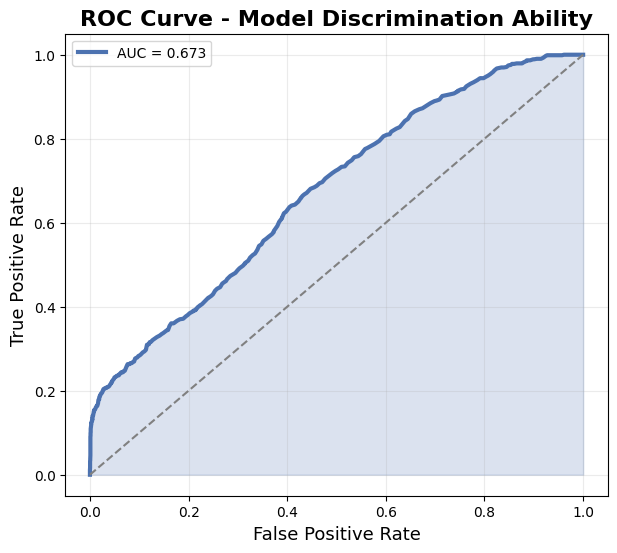

```python
plt.figure(figsize=(7,6))

plt.plot(fpr, tpr, color="#4C72B0", linewidth=3, label=f"AUC = {roc_auc:.3f}")
plt.plot([0,1], [0,1], linestyle="--", color="gray", linewidth=1.5)

plt.fill_between(fpr, tpr, alpha=0.2, color="#4C72B0")

plt.title("ROC Curve - Model Discrimination Ability", fontsize=16, weight="bold")
plt.xlabel("False Positive Rate", fontsize=13)
plt.ylabel("True Positive Rate", fontsize=13)
plt.grid(alpha=0.25)

plt.legend(frameon=True)
plt.show()
```

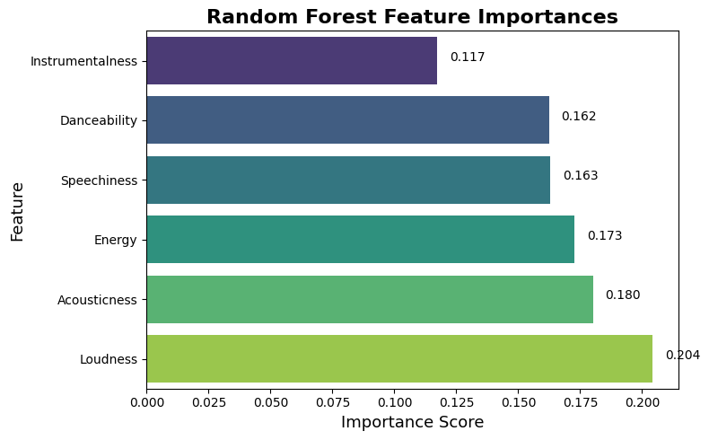

```python
importances = log_model.feature_importances_
feat_df = pd.DataFrame({
    "Feature": X.columns,
    "Importance": importances
}).sort_values(by="Importance", ascending=False)

plt.figure(figsize=(8,5))

feat_df_sorted = feat_df.sort_values(by="Importance", ascending=True)

sns.barplot(
    data=feat_df_sorted,
    x="Importance",
    y="Feature",
    hue="Feature",
    palette="viridis",
    legend=False
)

plt.title("Random Forest Feature Importances", fontsize=16, weight="bold")
plt.xlabel("Importance Score", fontsize=13)
plt.ylabel("Feature", fontsize=13)

for index, value in enumerate(feat_df_sorted["Importance"]):
    plt.text(value + 0.005, index, f"{value:.3f}", fontsize=10)

plt.tight_layout()
plt.show()
```

The bar plot above shows which features the Random Forest model relies on most when making predictions. Each bar is labeled, and the height reflects how strongly that feature influences the model. The top features contribute the most to distinguishing viral from non-viral songs, while lower features still provide useful supporting signals. Overall, this visualization highlights that the model is picking up meaningful patterns in the data and using them consistently to guide its decisions.

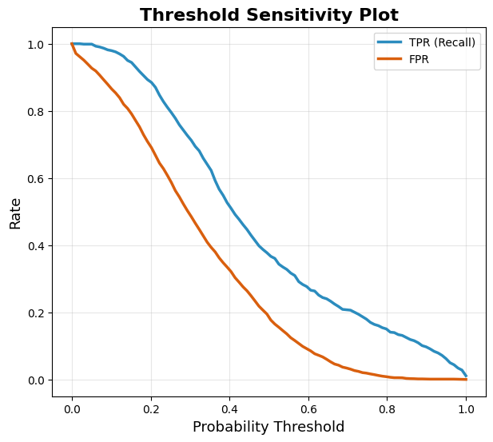

```python
thresholds = np.linspace(0,1,100)
tprs = []
fprs = []

for t in thresholds:
    preds = (y_prob >= t).astype(int)
    cm = confusion_matrix(y_test, preds)
    tn, fp, fn, tp = cm.ravel()
    tprs.append(tp / (tp + fn))
    fprs.append(fp / (fp + tn))

plt.figure(figsize=(7,6))
plt.plot(thresholds, tprs, label="TPR (Recall)", color="#2B8CBE", linewidth=2.5)
plt.plot(thresholds, fprs, label="FPR", color="#D95F0E", linewidth=2.5)

plt.title("Threshold Sensitivity Plot", fontsize=16, weight="bold")
plt.xlabel("Probability Threshold", fontsize=13)
plt.ylabel("Rate", fontsize=13)
plt.legend()
plt.grid(alpha=0.3)
plt.show()
```

The threshold sensitivity plot shows how the model’s behavior changes as the decision threshold moves from 0 to 1. The TPR curve highlights how recall increases at lower thresholds and decreases at higher ones, since stricter thresholds make the model predict fewer viral songs. The FPR curve rises when the threshold is low because the model becomes more willing to label a song as viral. Together, the two curves show the trade-off between identifying more viral tracks and keeping false positives low, which helps in selecting a threshold that matches the goals of the analysis.

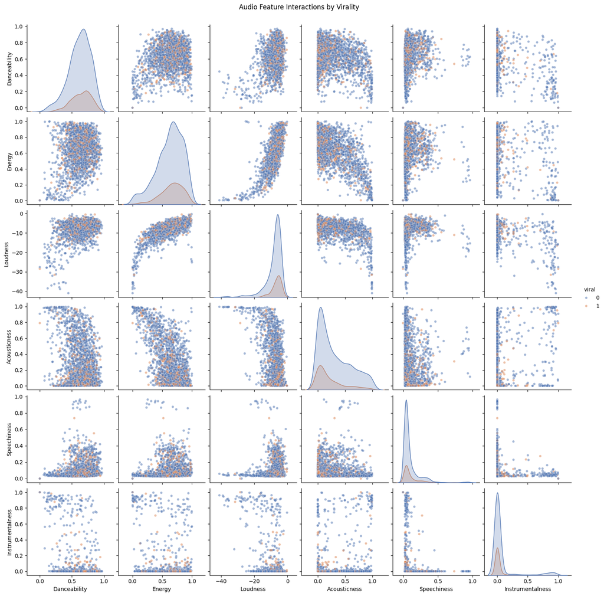

```python
sns.pairplot(
    df.sample(2000),
    vars=["Danceability", "Energy", "Loudness",
          "Acousticness", "Speechiness", "Instrumentalness"],
    hue="viral",
    palette=["#4c72b0", "#dd8452"],
    diag_kind="kde",
    plot_kws={"alpha": 0.5, "s": 20}
)
plt.suptitle("Audio Feature Interactions by Virality", y=1.02)
plt.show()
```

The pairplot highlights how different audio features relate to one another for viral and non-viral songs. Each scatterplot shows how two features interact, and the color coding makes it easy to see where viral tracks tend to cluster. The diagonal density plots give a quick view of how each feature is distributed within each group. Overall, this visualization helps reveal patterns in energy, danceability, loudness, and other traits that may influence virality, and it provides a clear sense of how the two classes overlap or separate across multiple dimensions.

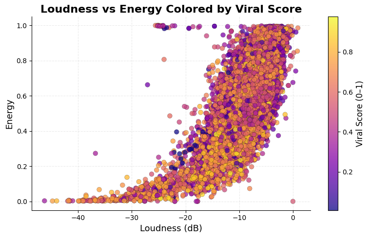

```python
fig, ax = plt.subplots(figsize=(8,5))

scatter = ax.scatter(
    df["Loudness"],
    df["Energy"],
    c=df["viral_score"],
    cmap="plasma",
    alpha=0.75,
    s=50,
    edgecolor="black",
    linewidth=0.2
)

cbar = plt.colorbar(scatter)
cbar.set_label("Viral Score (0–1)", fontsize=12)

plt.title("Loudness vs Energy Colored by Viral Score", fontsize=16, weight="bold")
plt.xlabel("Loudness (dB)", fontsize=13)
plt.ylabel("Energy", fontsize=13)

sns.despine()
plt.grid(alpha=0.25, linestyle="--")
plt.tight_layout()
plt.show()
```

This scatter plot illustrates the relationship between a track's loudness and energy, with each point representing a song and colored according to its viral score. The color gradient, displayed in the accompanying colorbar, indicates the level of virality from low to high. The plot makes it easy to see how songs with different loudness and energy levels correspond to varying viral scores, highlighting patterns in how audio characteristics may relate to a track's popularity. The use of transparency, edge outlines, and gridlines helps improve clarity and visual distinction between points.

# **Insights and Conclusion**

It is easier for the model to know when a song is not going to be viral rather than predicting when it will be viral. The model performed strongly on the non-viral class (F1-score: 0.83) but poorly on the viral class (F1-score: 0.35). This suggests the current features are effective at filtering out songs that lack the basic ingredients for mass success, but they are insufficient to predict a hit with high confidence.